# Table of Contents

**Kernel Author:**  
[Bhishan Poudel, Data Scientist, Ph.D Astrophysics](https://bhishanpdl.github.io/) .

# Data Description

> The datasets contains transactions made by credit cards in September 2013 by european cardholders.

> This dataset presents transactions that occurred in two days, where we have 492 frauds out of 284,807 transactions.

> The dataset is highly unbalanced, the positive class (frauds) account for 0.172% of all transactions.

> It contains only numerical input variables which are the result of a PCA transformation.

> Unfortunately, due to confidentiality issues, we cannot provide the original features and more background information about the data.

> Features V1, V2, ... V28 are the principal components obtained with PCA, the only features which have not been transformed with PCA are 'Time' and 'Amount'.

> Feature 'Time' contains the seconds elapsed between each transaction and the first transaction in the dataset. The feature 'Amount' is the transaction Amount, this feature can be used for example-dependant cost-senstive learning.

> Feature 'Class' is the response variable and it takes value 1 in case of fraud and 0 otherwise.m

# Business Problem

# Introduction to Boosting

The term Boosting refers to a family of algorithms which converts weak learner to strong learners.

There are many boosting algorithms:

```
sklearn.ensemble.GradientBoostingRegressor
xgboost.XGBRegressor # fast and best
lightgbm.LGBMRegressor # extreme fast, little acc than xgb
catboost.CatBoostRegressor # good for categorical feats
```

# Colab

```python
%%capture
import sys
ENV_COLAB = 'google.colab' in sys.modules

if ENV_COLAB:
    #!pip install hpsklearn
    !pip install shap eli5 lime scikit-plot watermark
    !pip install optuna hyperopt
    !pip install catboost
    !pip install ipywidgets
    !pip install -U scikit-learn
    !jupyter nbextension enable --py widgetsnbextension

    # create project like folders
    !mkdir -p ../outputs ../images ../reports ../html ../models

    print('Environment: Google Colab')
```

# Imports

```python
import time

notebook_start_time = time.time()
```

```python
import numpy as np
import pandas as pd

pd.set_option('max_columns',100)

# random state
SEED = 0
RNG = np.random.RandomState(SEED)

# visualizatioin
import matplotlib.pyplot as plt
plt.rcParams['figure.figsize'] = 8,8
plt.rcParams.update({'font.size': 16})
plt.style.use('ggplot')
%matplotlib inline
import seaborn as sns
sns.set(color_codes=True)

# six and pickle
import six
import pickle
import joblib

# mixed
import copy
import pprint
pp = pprint.PrettyPrinter(indent=4)

# sklearn
import sklearn

# classifiers
from sklearn.linear_model import LogisticRegression
from sklearn.svm import SVC
from sklearn.neighbors import KNeighborsClassifier
from sklearn.tree import DecisionTreeClassifier
from sklearn.ensemble import RandomForestClassifier

# scale and split
from sklearn.preprocessing import MinMaxScaler, StandardScaler, RobustScaler
from sklearn.model_selection import train_test_split
from sklearn.model_selection import StratifiedKFold

# sklearn scalar metrics
from sklearn.metrics import accuracy_score
from sklearn.metrics import precision_score
from sklearn.metrics import recall_score
from sklearn.metrics import f1_score

# roc auc and curves
from sklearn.metrics import auc
from sklearn.metrics import roc_auc_score
from sklearn.metrics import roc_curve
from sklearn.metrics import precision_recall_curve

# confusion matrix and classification report
from sklearn.metrics import confusion_matrix
from sklearn.metrics import classification_report

# boosting
import xgboost, lightgbm, catboost
import xgboost as xgb
import lightgbm as lgb
from sklearn.ensemble import GradientBoostingRegressor
from xgboost import XGBClassifier, DMatrix
from lightgbm import LGBMClassifier, Dataset
from catboost import CatBoostClassifier, Pool, CatBoost

# parameters tuning
from hyperopt import hp, tpe, fmin, Trials, STATUS_OK, STATUS_FAIL
from hyperopt.pyll import scope
from hyperopt.pyll.stochastic import sample

# model intepretation modules
import eli5
import shap
import yellowbrick
import lime
import scikitplot

# version
%load_ext watermark
%watermark -a "Bhishan Poudel" -d -v -m
print()
%watermark -iv
```

```
The watermark extension is already loaded. To reload it, use:
  %reload_ext watermark
Bhishan Poudel 2021-08-08

CPython 3.7.7
IPython 7.22.0

compiler   : Clang 4.0.1 (tags/RELEASE_401/final)
system     : Darwin
release    : 19.6.0
machine    : x86_64
processor  : i386
CPU cores  : 4
interpreter: 64bit

joblib      1.0.1
sklearn     0.23.1
seaborn     0.11.0
shap        0.39.0
xgboost     1.2.0
catboost    0.23.2
eli5        0.10.1
autopep8    1.5.2
six         1.15.0
lightgbm    2.3.1
yellowbrick 1.1
json        2.0.9
scikitplot  0.3.7
pandas      1.3.0
numpy       1.19.5
```

# Useful Scripts

```python
# my local library
import sys
sys.path.append("/Users/poudel/Dropbox/a00_Bhishan_Modules/bhishan")
from bhishan import bp
```

```python
def model_evaluation(model_name, desc, ser_ytrain, trprobs1d,
                     df_eval=None,threshold=0.5,
                     show=True,col_sort='Recall'):
    if df_eval is None:
        df_eval = pd.DataFrame({'Model': [],
                        'Description':[],
                        'Accuracy':[],
                        'Precision':[],
                        'Recall':[],
                        'F1':[],
                        'AUC':[],
                        'AUCPR':[],
                    })

    ytr = np.array(ser_ytrain).flatten()
    prec,rec,thr = sklearn.metrics.precision_recall_curve(ytr,trprobs1d)
    auc_pr = sklearn.metrics.auc(rec,prec)

    # model evaluation
    average = 'binary'
    row_eval = [model_name,desc,
                sklearn.metrics.accuracy_score(ytr, trpreds),
                sklearn.metrics.precision_score(ytr, trpreds, average=average),
                sklearn.metrics.recall_score(ytr, trpreds, average=average),
                sklearn.metrics.f1_score(ytr, trpreds, average=average),
                sklearn.metrics.roc_auc_score(ytr, trprobs1d), # auc need probs
                auc_pr
                ]

    df_eval.loc[len(df_eval)] = row_eval
    df_eval = df_eval.drop_duplicates()
    df_eval = df_eval.sort_values(col_sort,ascending=False)

    if show:
        display(df_eval.style.background_gradient(subset=[col_sort]))

    return df_eval

df_eval = None
```

# Load the data

```python
ifile = 'https://github.com/bhishanpdl/Datasets/blob/master/Projects/Fraud_detection/raw/creditcard.csv.zip?raw=true'
df = pd.read_csv(ifile,compression='zip')
print(df.shape)
df.head()
```

```
(284807, 31)
```

|  | Time | V1 | V2 | V3 | V4 | V5 | V6 | V7 | V8 | V9 | ... | V21 | V22 | V23 | V24 | V25 | V26 | V27 | V28 | Amount | Class |
| --- | --- | --- | --- | --- | --- | --- | --- | --- | --- | --- | --- | --- | --- | --- | --- | --- | --- | --- | --- | --- | --- |
| 0 | 0.0 | -1.359807 | -0.072781 | 2.536347 | 1.378155 | -0.338321 | 0.462388 | 0.239599 | 0.098698 | 0.363787 | ... | -0.018307 | 0.277838 | -0.110474 | 0.066928 | 0.128539 | -0.189115 | 0.133558 | -0.021053 | 149.62 | 0 |
| 1 | 0.0 | 1.191857 | 0.266151 | 0.166480 | 0.448154 | 0.060018 | -0.082361 | -0.078803 | 0.085102 | -0.255425 | ... | -0.225775 | -0.638672 | 0.101288 | -0.339846 | 0.167170 | 0.125895 | -0.008983 | 0.014724 | 2.69 | 0 |
| 2 | 1.0 | -1.358354 | -1.340163 | 1.773209 | 0.379780 | -0.503198 | 1.800499 | 0.791461 | 0.247676 | -1.514654 | ... | 0.247998 | 0.771679 | 0.909412 | -0.689281 | -0.327642 | -0.139097 | -0.055353 | -0.059752 | 378.66 | 0 |
| 3 | 1.0 | -0.966272 | -0.185226 | 1.792993 | -0.863291 | -0.010309 | 1.247203 | 0.237609 | 0.377436 | -1.387024 | ... | -0.108300 | 0.005274 | -0.190321 | -1.175575 | 0.647376 | -0.221929 | 0.062723 | 0.061458 | 123.50 | 0 |
| 4 | 2.0 | -1.158233 | 0.877737 | 1.548718 | 0.403034 | -0.407193 | 0.095921 | 0.592941 | -0.270533 | 0.817739 | ... | -0.009431 | 0.798278 | -0.137458 | 0.141267 | -0.206010 | 0.502292 | 0.219422 | 0.215153 | 69.99 | 0 |

5 rows × 31 columns

```python
target = 'Class'
features = df.columns.drop(target)
df[target].value_counts(normalize=True)*100
```

```
0    99.827251
1     0.172749
Name: Class, dtype: float64
```

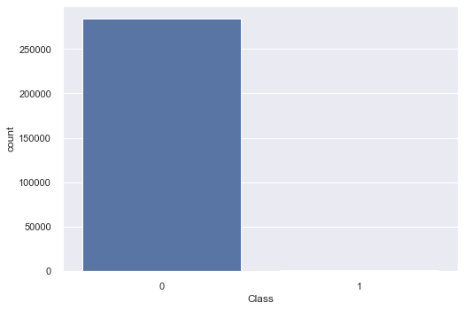

```python
sns.countplot(x=df[target])
```

# Train test split with stratify

```python
from sklearn.model_selection import train_test_split

df_Xtrain_orig, df_Xtest, ser_ytrain_orig, ser_ytest = train_test_split(
    df.drop(target,axis=1),
    df[target],
    test_size=0.2,
    random_state=SEED,
    stratify=df[target])

ytrain_orig = ser_ytrain_orig.to_numpy().ravel()
ytest = ser_ytest.to_numpy().ravel()

print(df_Xtrain_orig.shape)
df_Xtrain_orig.head()
```

```
(227845, 30)
```

|  | Time | V1 | V2 | V3 | V4 | V5 | V6 | V7 | V8 | V9 | ... | V20 | V21 | V22 | V23 | V24 | V25 | V26 | V27 | V28 | Amount |
| --- | --- | --- | --- | --- | --- | --- | --- | --- | --- | --- | --- | --- | --- | --- | --- | --- | --- | --- | --- | --- | --- |
| 36001 | 38355.0 | 1.043949 | 0.318555 | 1.045810 | 2.805989 | -0.561113 | -0.367956 | 0.032736 | -0.042333 | -0.322674 | ... | -0.084556 | -0.240105 | -0.680315 | 0.085328 | 0.684812 | 0.318620 | -0.204963 | 0.001662 | 0.037894 | 49.67 |
| 12844 | 22555.0 | -1.665159 | 0.808440 | 1.805627 | 1.903416 | -0.821627 | 0.934790 | -0.824802 | 0.975890 | 1.747469 | ... | -0.373759 | -0.335332 | -0.510994 | 0.035839 | 0.147565 | -0.529358 | -0.566950 | -0.595998 | -0.220086 | 16.94 |
| 2873 | 2431.0 | -0.324096 | 0.601836 | 0.865329 | -2.138000 | 0.294663 | -1.251553 | 1.072114 | -0.334896 | 1.071268 | ... | -0.039868 | 0.012220 | 0.352856 | -0.341505 | -0.145791 | 0.094194 | -0.804026 | 0.229428 | -0.021623 | 1.00 |
| 145263 | 86773.0 | -0.258270 | 1.217501 | -0.585348 | -0.875347 | 1.222481 | -0.311027 | 1.073860 | -0.161408 | 0.200665 | ... | 0.382305 | -0.424626 | -0.781158 | 0.019316 | 0.178614 | -0.315616 | 0.096665 | 0.269740 | -0.020635 | 10.78 |
| 186658 | 127202.0 | 2.142162 | -0.494988 | -1.936511 | -0.818288 | -0.025213 | -1.027245 | -0.151627 | -0.305750 | -0.869482 | ... | 0.106592 | 0.010115 | 0.021722 | 0.079463 | -0.480899 | 0.023846 | -0.279076 | -0.030121 | -0.043888 | 39.96 |

5 rows × 30 columns

# Train Validation with stratify

```python
df_Xtrain, df_Xvalid, ser_ytrain, ser_yvalid = train_test_split(
    df_Xtrain_orig,
    ser_ytrain_orig,
    test_size=0.2,
    random_state=SEED,
    stratify=ser_ytrain_orig)

ytrain = ser_ytrain.to_numpy().ravel()
yvalid = ser_yvalid.to_numpy().ravel()

print(df_Xtrain.shape)
```

```
(182276, 30)
```

# Modelling catboost

https://catboost.ai/docs/concepts/python-reference_catboostregressor.html

```
class CatBoostRegressor(

iterations=None,                 learning_rate=None,
depth=None,                      l2_leaf_reg=None,
model_size_reg=None,             rsm=None,
loss_function='RMSE',            border_count=None,
feature_border_type=None,        per_float_feature_quantization=None,
input_borders=None,              output_borders=None,
fold_permutation_block=None,     od_pval=None,
od_wait=None,                    od_type=None,
nan_mode=None,                   counter_calc_method=None,
leaf_estimation_iterations=None, leaf_estimation_method=None,
thread_count=None,               random_seed=None,
use_best_model=None,             best_model_min_trees=None,
verbose=None,                    silent=None,
logging_level=None,              metric_period=None,
ctr_leaf_count_limit=None,       store_all_simple_ctr=None,
max_ctr_complexity=None,         has_time=None,
allow_const_label=None,          one_hot_max_size=None,
random_strength=None,name=None,  ignored_features=None,
train_dir=None,                  custom_metric=None,
eval_metric=None,                bagging_temperature=None,
save_snapshot=None,              snapshot_file=None,
snapshot_interval=None,          fold_len_multiplier=None,
used_ram_limit=None,             gpu_ram_part=None,
pinned_memory_size=None,         allow_writing_files=None,
final_ctr_computation_mode=None, approx_on_full_history=None,
boosting_type=None,              simple_ctr=None,
combinations_ctr=None,           per_feature_ctr=None,
ctr_target_border_count=None,    task_type=None,
device_config=None,              devices=None,
bootstrap_type=None,             subsample=None,
sampling_unit=None,              dev_score_calc_obj_block_size=None,
max_depth=None,                  n_estimators=None,
num_boost_round=None,            num_trees=None,
colsample_bylevel=None,          random_state=None,
reg_lambda=None,                 objective=None,
eta=None,                        max_bin=None,
gpu_cat_features_storage=None,   data_partition=None,
metadata=None,                   early_stopping_rounds=None,
cat_features=None,               grow_policy=None,
min_data_in_leaf=None,           min_child_samples=None,
max_leaves=None,                 num_leaves=None,
score_function=None,             leaf_estimation_backtracking=None,
ctr_history_unit=None,           monotone_constraints=None
)
```

```python
import catboost
bp.show_methods(catboost,2)
```

|  | 0 | 1 |
| --- | --- | --- |
| 0 | CatBoost | Pool |
| 1 | CatBoostClassifier | core |
| 2 | CatBoostError | cv |
| 3 | CatBoostRegressor | sum_models |
| 4 | CatboostError | to_classifier |
| 5 | EFstrType | to_regressor |
| 6 | FeaturesData | train |
| 7 | MetricVisualizer | version |
| 8 | MultiRegressionCustomMetric | widget |
| 9 | MultiRegressionCustomObjective |  |

```python
from catboost import CatBoostClassifier, Pool

bp.show_methods(CatBoostClassifier,2)
```

|  | 0 | 1 |
| --- | --- | --- |
| 0 | best_iteration_ | get_test_evals |
| 1 | best_score_ | get_text_feature_indices |
| 2 | calc_feature_statistics | get_tree_leaf_counts |
| 3 | calc_leaf_indexes | grid_search |
| 4 | classes_ | is_fitted |
| 5 | compare | iterate_leaf_indexes |
| 6 | copy | learning_rate_ |
| 7 | create_metric_calcer | load_model |
| 8 | drop_unused_features | plot_partial_dependence |
| 9 | eval_metrics | plot_predictions |
| 10 | evals_result_ | plot_tree |
| 11 | feature_importances_ | predict |
| 12 | feature_names_ | predict_log_proba |
| 13 | fit | predict_proba |
| 14 | get_all_params | random_seed_ |
| 15 | get_best_iteration | randomized_search |
| 16 | get_best_score | save_borders |
| 17 | get_borders | save_model |
| 18 | get_cat_feature_indices | score |
| 19 | get_evals_result | set_feature_names |
| 20 | get_feature_importance | set_leaf_values |
| 21 | get_leaf_values | set_params |
| 22 | get_leaf_weights | set_scale_and_bias |
| 23 | get_metadata | shrink |
| 24 | get_object_importance | staged_predict |
| 25 | get_param | staged_predict_log_proba |
| 26 | get_params | staged_predict_proba |
| 27 | get_scale_and_bias | tree_count_ |
| 28 | get_test_eval |  |

```python
from catboost import CatBoostClassifier
from sklearn.model_selection import StratifiedKFold
from sklearn.model_selection import cross_val_score, cross_val_predict
from sklearn.metrics import accuracy_score,  precision_score, recall_score,f1_score
from sklearn.metrics import confusion_matrix
from sklearn import model_selection

# time
time_start = time.time()

# current parameters
desc = 'default,random_state=100, cross_validation_ypreds'

Xtr = df_Xtrain.to_numpy()
ytr = ser_ytrain.to_numpy().ravel()
Xtx = df_Xtest.to_numpy()
ytx = ser_ytest.to_numpy().ravel()

# fit the model
model = CatBoostClassifier(verbose=100,random_state=SEED)
model.fit(Xtr, ytr)

# save the model
# joblib.dump(model_cat, 'model_cat.pkl')
# model_cat = joblib.load('model_cat.pkl')

# predictions
skf = model_selection.StratifiedKFold(n_splits=2,shuffle=True,random_state=SEED)
trprobs_cv = model_selection.cross_val_predict(model, df_Xtrain, ser_ytrain,
                               cv=skf,method='predict_proba')
trprobs1d = trprobs_cv[:,1] # take 2nd column for probability

threshold = 0.5
trpreds = (trprobs1d>threshold).astype(np.int8)

# model evaluation
df_eval = model_evaluation('catboost', desc, ytr,trprobs1d,df_eval=df_eval)

time_taken = time.time() - time_start
print('Time taken: {:.0f} min {:.0f} secs'.format(*divmod(time_taken,60)))
display(df_eval)
```

```
Learning rate set to 0.095119
0:	learn: 0.3780861	total: 124ms	remaining: 2m 4s
100:	learn: 0.0016198	total: 5.19s	remaining: 46.2s
200:	learn: 0.0010673	total: 10.3s	remaining: 40.9s
300:	learn: 0.0008012	total: 15.5s	remaining: 35.9s
400:	learn: 0.0005683	total: 20.5s	remaining: 30.6s
500:	learn: 0.0003989	total: 25.6s	remaining: 25.5s
600:	learn: 0.0002876	total: 30.8s	remaining: 20.4s
700:	learn: 0.0002030	total: 35.8s	remaining: 15.3s
800:	learn: 0.0001605	total: 40.8s	remaining: 10.1s
900:	learn: 0.0001330	total: 46.1s	remaining: 5.06s
999:	learn: 0.0001102	total: 51s	remaining: 0us
Learning rate set to 0.07075
0:	learn: 0.4576720	total: 63.9ms	remaining: 1m 3s
100:	learn: 0.0014048	total: 3.19s	remaining: 28.4s
200:	learn: 0.0007900	total: 6.25s	remaining: 24.9s
300:	learn: 0.0004575	total: 9.32s	remaining: 21.6s
400:	learn: 0.0002501	total: 12.4s	remaining: 18.5s
500:	learn: 0.0001718	total: 15.5s	remaining: 15.4s
600:	learn: 0.0001308	total: 18.5s	remaining: 12.3s
700:	learn: 0.0001045	total: 21.7s	remaining: 9.26s
800:	learn: 0.0000867	total: 24.8s	remaining: 6.15s
900:	learn: 0.0000768	total: 27.8s	remaining: 3.05s
999:	learn: 0.0000661	total: 30.8s	remaining: 0us
Learning rate set to 0.07075
0:	learn: 0.4631036	total: 33.1ms	remaining: 33s
100:	learn: 0.0018651	total: 3.08s	remaining: 27.4s
200:	learn: 0.0011770	total: 6.14s	remaining: 24.4s
300:	learn: 0.0008368	total: 9.23s	remaining: 21.4s
400:	learn: 0.0005437	total: 13s	remaining: 19.4s
500:	learn: 0.0003737	total: 16s	remaining: 16s
600:	learn: 0.0002749	total: 19.1s	remaining: 12.7s
700:	learn: 0.0002123	total: 22.5s	remaining: 9.6s
800:	learn: 0.0001767	total: 25.6s	remaining: 6.35s
900:	learn: 0.0001466	total: 28.6s	remaining: 3.14s
999:	learn: 0.0001254	total: 31.6s	remaining: 0us
```

|  | Model | Description | Accuracy | Precision | Recall | F1 | AUC | AUCPR |
| --- | --- | --- | --- | --- | --- | --- | --- | --- |
| 0 | catboost | default,random_state=100, cross_validation_ypreds | 0.999534 | 0.945736 | 0.774603 | 0.851658 | 0.965710 | 0.827831 |

```
Time taken: 1 min 55 secs
```

|  | Model | Description | Accuracy | Precision | Recall | F1 | AUC | AUCPR |
| --- | --- | --- | --- | --- | --- | --- | --- | --- |
| 0 | catboost | default,random_state=100, cross_validation_ypreds | 0.999534 | 0.945736 | 0.774603 | 0.851658 | 0.96571 | 0.827831 |

```python
%%time
model = CatBoostClassifier(verbose=100,random_state=SEED)
model.fit(Xtr, ytr)
joblib.dump(model, '../models/model_cat_default_seed100.joblib')

ypreds = model.predict(Xtx)
cm = sklearn.metrics.confusion_matrix(ytx,ypreds)
print('confusion matrix\n',cm)
```

```
Learning rate set to 0.095119
0:	learn: 0.3780861	total: 62.7ms	remaining: 1m 2s
100:	learn: 0.0016198	total: 5.1s	remaining: 45.4s
200:	learn: 0.0010673	total: 10.1s	remaining: 40.2s
300:	learn: 0.0008012	total: 15.3s	remaining: 35.5s
400:	learn: 0.0005683	total: 21.8s	remaining: 32.6s
500:	learn: 0.0003989	total: 30.9s	remaining: 30.8s
600:	learn: 0.0002876	total: 35.9s	remaining: 23.8s
700:	learn: 0.0002030	total: 40.8s	remaining: 17.4s
800:	learn: 0.0001605	total: 45.7s	remaining: 11.4s
900:	learn: 0.0001330	total: 51s	remaining: 5.6s
999:	learn: 0.0001102	total: 58s	remaining: 0us
confusion matrix
 [[56859     5]
 [   24    74]]
CPU times: user 1min 56s, sys: 16 s, total: 2min 12s
Wall time: 58.7 s
```

```python
yprobs = model.predict_proba(Xtx)
print(yprobs[:5])
```

```
[[9.99998192e-01 1.80796544e-06]
 [9.99932577e-01 6.74226697e-05]
 [9.99998670e-01 1.32969613e-06]
 [9.99996711e-01 3.28938804e-06]
 [9.99994773e-01 5.22686104e-06]]
```

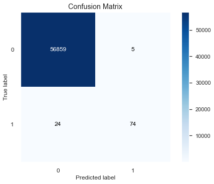

```python
from scikitplot import metrics as skpmetrics

skpmetrics.plot_confusion_matrix(ytx, ypreds)
```

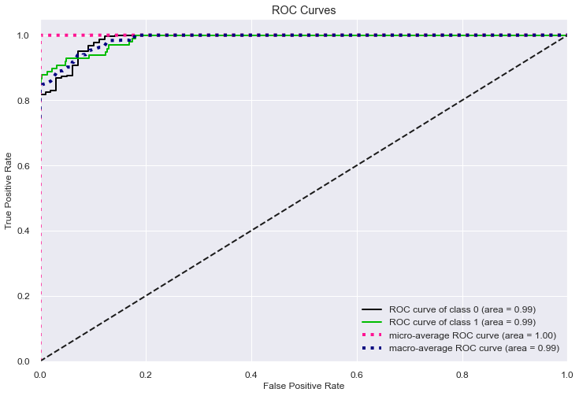

```python
fig, ax = plt.subplots(figsize=(12,8))
skpmetrics.plot_roc(ytx,yprobs,ax=ax)
```

```python
import eli5

# eli5.explain_weights_catboost(model) # same thing
eli5.show_weights(model)
```

| Weight | Feature |
| --- | --- |
| 0.0787 | 1 |
| 0.0637 | 8 |
| 0.0607 | 14 |
| 0.0535 | 4 |
| 0.0519 | 26 |
| 0.0456 | 29 |
| 0.0428 | 0 |
| 0.0391 | 12 |
| 0.0390 | 22 |
| 0.0384 | 17 |
| 0.0382 | 3 |
| 0.0336 | 13 |
| 0.0320 | 20 |
| 0.0284 | 15 |
| 0.0283 | 25 |
| 0.0283 | 18 |
| 0.0276 | 2 |
| 0.0271 | 10 |
| 0.0258 | 24 |
| 0.0245 | 5 |
| *… 10 more …* |  |

# Catboost with validation set

```python
df_Xtrain.head(2)
```

|  | Time | V1 | V2 | V3 | V4 | V5 | V6 | V7 | V8 | V9 | ... | V20 | V21 | V22 | V23 | V24 | V25 | V26 | V27 | V28 | Amount |
| --- | --- | --- | --- | --- | --- | --- | --- | --- | --- | --- | --- | --- | --- | --- | --- | --- | --- | --- | --- | --- | --- |
| 138257 | 82565.0 | 1.118591 | 0.562709 | 0.569628 | 2.987496 | -0.365594 | -0.531789 | -0.044144 | 0.011932 | -0.129131 | ... | -0.204184 | -0.128269 | -0.218875 | -0.048816 | 0.617265 | 0.551384 | 0.06022 | 0.016136 | 0.047100 | 7.6 |
| 60033 | 49125.0 | 1.170686 | 0.083759 | 0.466278 | 0.913911 | -0.093123 | 0.427588 | -0.372727 | 0.312777 | 0.129610 | ... | -0.226078 | -0.176121 | -0.584726 | 0.066051 | -0.746667 | 0.232641 | -0.54774 | 0.038060 | 0.010995 | 3.9 |

2 rows × 30 columns

```python
# # time
# time_start = time.time()

# # current parameters
# Xtr = df_Xtrain
# ytr = ser_ytrain.to_numpy().ravel()
# Xtx = df_Xtest
# ytx = ser_ytest.to_numpy().ravel()
# Xvd = df_Xvalid
# yvd = ser_yvalid.to_numpy().ravel()

# # fit the model
# model = CatBoostClassifier(random_state=0,verbose=100)
# model.fit(Xtr, ytr,
#           eval_set=(Xvd, yvd))

# # ypreds
# ypreds = model.predict(Xtx)

# # r-squared values
# auc = roc_auc_score(ytx, ypreds)

# # time
# time_taken = time.time() - time_start
# print('Time taken: {:.0f} min {:.0f} secs'.format(*divmod(time_taken,60)))
# print('ROC AUC Score ', auc)
```

# Feature Statistics

[catboost tutorials model analysis feature statistics tutorial](https://github.com/catboost/tutorials/blob/master/model_analysis/feature_statistics_tutorial.ipynb)

```python
df_Xtrain.head(2)
```

|  | Time | V1 | V2 | V3 | V4 | V5 | V6 | V7 | V8 | V9 | V10 | V11 | V12 | V13 | V14 | V15 | V16 | V17 | V18 | V19 | V20 | V21 | V22 | V23 | V24 | V25 | V26 | V27 | V28 | … |
| --- | --- | --- | --- | --- | --- | --- | --- | --- | --- | --- | --- | --- | --- | --- | --- | --- | --- | --- | --- | --- | --- | --- | --- | --- | --- | --- | --- | --- | --- | --- |
| 138257 | 82565.0 | 1.118591 | 0.562709 | 0.569628 | 2.987496 | -0.365594 | -0.531789 | -0.044144 | 0.011932 | -0.129131 | 0.084908 | -0.540334 | -0.405535 | -1.124493 | -1.118716 | -0.708344 | 0.403485 | 0.890145 | -0.025385 | -0.901995 | -0.204184 | -0.128269 | -0.218875 | -0.048816 | 0.617265 | 0.551384 | 0.06022 | 0.016136 | 0.047100 | … |
| 60033 | 49125.0 | 1.170686 | 0.083759 | 0.466278 | 0.913911 | -0.093123 | 0.427588 | -0.372727 | 0.312777 | 0.129610 | 0.188107 | 0.707980 | 0.025212 | -1.341491 | 0.695831 | 0.890826 | 0.588590 | -0.703943 | 0.247763 | -0.221215 | -0.226078 | -0.176121 | -0.584726 | 0.066051 | -0.746667 | 0.232641 | -0.54774 | 0.038060 | 0.010995 | … |

```python
model = CatBoostClassifier(verbose=100,random_state=SEED)
model.fit(Xtr, ytr)

# float feature
feature_name = 'Amount'
dict_stats = model.calc_feature_statistics(df_Xtrain, ser_ytrain, feature_name, plot=True)
```

```
Learning rate set to 0.095119
0:	learn: 0.3780861	total: 55.2ms	remaining: 55.1s
100:	learn: 0.0016198	total: 5.37s	remaining: 47.8s
200:	learn: 0.0010673	total: 10.5s	remaining: 41.7s
300:	learn: 0.0008012	total: 15.7s	remaining: 36.4s
400:	learn: 0.0005683	total: 20.8s	remaining: 31s
500:	learn: 0.0003989	total: 25.8s	remaining: 25.7s
600:	learn: 0.0002876	total: 35.2s	remaining: 23.4s
700:	learn: 0.0002030	total: 40.5s	remaining: 17.3s
800:	learn: 0.0001605	total: 47.2s	remaining: 11.7s
900:	learn: 0.0001330	total: 59.5s	remaining: 6.54s
999:	learn: 0.0001102	total: 1m 6s	remaining: 0us
```

[output not shown]

# Feature Importance

```python
# feature importance
df_imp = pd.DataFrame({'Feature': features,
                       'Importance': model.feature_importances_
                       })

df_imp.sort_values('Importance',ascending=False).style.background_gradient()
```

```python
def plot_feature_imp_catboost(model_catboost,features):
    """Plot the feature importance horizontal bar plot.

    """

    df_imp = pd.DataFrame({'Feature': model.feature_names_,
                        'Importance': model.feature_importances_
                        })

    df_imp = df_imp.sort_values('Importance').set_index('Feature')
    ax = df_imp.plot.barh(figsize=(12,8))

    plt.grid(True)
    plt.title('Feature Importance',fontsize=14)
    ax.get_legend().remove()

    for p in ax.patches:
        x = p.get_width()
        y = p.get_y()
        text = '{:.2f}'.format(p.get_width())
        ax.text(x, y,text,fontsize=15,color='indigo')

    plt.show()

plot_feature_imp_catboost(model, features)
```

[output not shown]

```python
df_fimp = model.get_feature_importance(prettified=True)
df_fimp.head()
```

```python
plt.figure(figsize=(12,8))
ax = sns.barplot(x=df_fimp.columns[1], y=df_fimp.columns[0], data=df_fimp);

for p in ax.patches:
    x = p.get_width()
    y = p.get_y()
    text = '{:.2f}'.format(p.get_width())
    ax.text(x, y,text,fontsize=15,color='indigo',va='top',ha='left')
```

[output not shown]

# catboost using Pool

```python
from catboost import CatBoost, Pool
```

```python
# help(CatBoost)
```

```python
cat_features = [] # take it empty for the moment
dtrain = Pool(df_Xtrain, ser_ytrain, cat_features=cat_features)
dvalid = Pool(df_Xvalid, ser_yvalid, cat_features=cat_features)
dtest = Pool(df_Xtest, ser_ytest, cat_features=cat_features)
```

```python
params_cat = {'iterations': 100, 'verbose': False,
          'random_seed': 0,
          'eval_metric':'AUC',
          'loss_function':'Logloss',
          'cat_features': [],
          'ignored_features': [],
          'early_stopping_rounds': 200,
          'verbose': 200,
          }

bst_cat = CatBoost(params=params_cat)

bst_cat.fit(dtrain,
            eval_set=(df_Xvalid, ser_yvalid),
          use_best_model=True,
          plot=True);

print(bst_cat.eval_metrics(dtest, ['AUC'])['AUC'][-1])
```

# Cross Validation

- [Catboost CV](https://catboost.ai/docs/concepts/python-usages-examples.html)
- [Catboost Jupyter Notebook visulization](https://catboost.ai/docs/features/visualization_jupyter-notebook.html)

```
cv(pool=None, params=None, dtrain=None, iterations=None,
num_boost_round=None, fold_count=None, nfold=None, inverted=False,
partition_random_seed=0, seed=None, shuffle=True, logging_level=None,
stratified=None, as_pandas=True, metric_period=None, verbose=None,
verbose_eval=None, plot=False, early_stopping_rounds=None,
save_snapshot=None, snapshot_file=None,
snapshot_interval=None, folds=None, type='Classical')
```

```python
params = {'iterations': 100, 'verbose': False,
          'random_seed': 0,
          'loss_function':'Logloss',
          'eval_metric':'AUC',
          }

df_scores = catboost.cv(dtrain,
            params,
            fold_count=2,
            verbose=100,
            shuffle=True,
            stratified=True,
            plot="True") # plot does not work in google colab
```

```python
print(df_scores.columns)
df_scores.head()
```

```python
sns.lineplot(x='iterations',y='train-Logloss-mean',data=df_scores,ax=ax,color='r')
sns.lineplot(x='iterations',y='test-Logloss-mean',data=df_scores,ax=ax,
             color='b',alpha=0.2,linewidth=5,linestyle='--')

plt.show()
```

[output not shown]

# HPO (Hyper Parameter Optimization)

We generally should optimize model complexity and then tune the convergence.

model complexity: max_depth etc convergence: learning rate

Parameters:

- learning_rate: step size shrinkage used to prevent overfitting. Range is [0,1]
- depth: determines how deeply each tree is allowed to grow during any boosting round.
- subsample: percentage of samples used per tree. Low value can lead to underfitting.
- colsample_bytree: percentage of features used per tree. High value can lead to overfitting.

## Baseline model

```python
model = joblib.load('../models/model_cat_default_seed100.joblib')
ypreds = model.predict(df_Xtest)
cm = confusion_matrix(ytest, ypreds)
print(cm)
```

## Using Early Stopping from Validation Set

```python
%%time
params = dict(verbose=500,
              random_state=0,
              iterations=3_000,
              eval_metric='AUC',
              cat_features = [],
              early_stopping_rounds=200,
            )

model = catboost.CatBoostClassifier(**params)

model.fit(df_Xtrain, ytrain,
          eval_set=(df_Xvalid, yvalid),
          use_best_model=True,
          plot=False
         );

# now use the best iteration
best_iter = model.get_best_iteration()

model = CatBoostClassifier(verbose=False,random_state=0,iterations=best_iter)
model.fit(df_Xtrain, ser_ytrain)
joblib.dump(model, '../models/model_cat_earlystopping.joblib')


ypreds = model.predict(df_Xtest)

cm = confusion_matrix(ytest, ypreds)
print(cm)

desc = f'early stopping, iterations={best_iter}'
df_eval = model_evaluation('catboost', desc, ytx,ypreds,df_eval=df_eval)

# using best iterations is worse, use previous 1000.
```

[output not shown]

```python
# for n in [6]: # default detpth = 6

#     model = CatBoostClassifier(verbose=False,random_state=0,
#                               iterations=1_000,
#                               depth=n,
#                               )
#     model.fit(Xtr, ytr)
#     ypreds = model.predict(Xtx)
#     cm = confusion_matrix(ytest, ypreds)
#     error = cm[0,1] + cm[1,0]
#     print(f'Confusion matrix error count = {error} for n = {n}')
```

## Try Your luck with different random states

```python
# for n in [0]:

#     model = CatBoostClassifier(verbose=False,random_state=n,
#                                depth=6,
#                               iterations=1_000,
#                               )
#     model.fit(Xtr, ytr)
#     ypreds = model.predict(Xtx)
#     cm = confusion_matrix(ytest, ypreds)
#     error = cm[0,1] + cm[1,0]
#     print(f'Confusion matrix error count = {error} for n = {n}')
```

## HPO Hyper Parameter Optimization with Optuna

- [optuna github catboost simple](https://github.com/optuna/optuna/blob/master/examples/catboost_simple.py)
- [catboost parameters list](https://catboost.ai/docs/concepts/python-reference_parameters-list.html)

```python
import optuna
optuna.logging.set_verbosity(optuna.logging.WARNING) # use INFO to see progress
```

```python
def objective(trial):

    params_cat_optuna = {
        'objective': trial.suggest_categorical('objective', ['Logloss', 'CrossEntropy']),
        'colsample_bylevel': trial.suggest_uniform('colsample_bylevel', 0.01, 0.1),
        'depth': trial.suggest_int('depth', 1, 12),
        'boosting_type': trial.suggest_categorical('boosting_type', ['Ordered', 'Plain']),
        'bootstrap_type': trial.suggest_categorical('bootstrap_type',
                                                    ['Bayesian', 'Bernoulli', 'MVS']),
        'used_ram_limit': '3gb'
    }

    # update parameters
    if params_cat_optuna['bootstrap_type'] == 'Bayesian':
        params_cat_optuna['bagging_temperature'] = trial.suggest_uniform('bagging_temperature', 0, 10)
    elif params_cat_optuna['bootstrap_type'] == 'Bernoulli':
        params_cat_optuna['subsample'] = trial.suggest_uniform('subsample', 0.1, 1)

    # fit the model
    model = CatBoostClassifier(random_state=SEED,**params_cat_optuna)
    model.fit(df_Xtrain, ser_ytrain,
            eval_set=[(df_Xvalid, ser_yvalid)],
            verbose=0,
            early_stopping_rounds=100)

    ypreds = model.predict(df_Xvalid)
    ypreds = np.rint(ypreds)
    score = roc_auc_score(ser_yvalid.to_numpy().ravel(),
                              ypreds)
    return score
```

```python
# NOTE: there is inherent non-determinism in optuna hyperparameter selection
#       we may not get the same hyperparameters when run twice.


sampler = optuna.samplers.TPESampler(seed=SEED)
N_TRIALS = 1 # make it large

study = optuna.create_study(direction='maximize',
                            sampler=sampler,
                            study_name='cat_optuna',
                            storage='sqlite:///cat_optuna_fraud_detection.db',
                            load_if_exists=True)

study.optimize(objective, n_trials=N_TRIALS,timeout=600)
```

```python
# Resume from last time
sampler = optuna.samplers.TPESampler(seed=SEED)
N_TRIALS = 1 # make it large

study = optuna.create_study(direction='maximize',
                            sampler=sampler,
                            study_name='cat_optuna',
                            storage='sqlite:///cat_optuna_fraud_detection.db',
                            load_if_exists=True)

# study.optimize(objective, n_trials=N_TRIALS)
```

```python
print(f'Number of finished trials: {len(study.trials)}')

# best trail
best_trial = study.best_trial

# best params
params_best = study.best_trial.params
params_best
```

```python
%%time

model_name = 'catboost'
desc = 'grid search optuna'
Xtr = df_Xtrain_orig
ytr = ser_ytrain_orig.to_numpy().ravel()
Xtx = df_Xtest
ytx = ser_ytest.to_numpy().ravel()
Xvd = df_Xvalid
yvd = ser_yvalid.to_numpy().ravel()

# use best model
params_best =  study.best_trial.params

clf = CatBoostClassifier(random_state=SEED,verbose=False)
clf.set_params(**params_best)

# fit and save the model
clf.fit(Xtr, ytr)
joblib.dump(clf,'../models/clf_cat_grid_search_optuna.pkl')

# load the saved model
clf = joblib.load('../models/clf_cat_grid_search_optuna.pkl')

# predictions
ypreds = clf.predict(Xtx)

# model evaluation
cm = confusion_matrix(ytx, ypreds)
print(cm)

desc = f'grid search optuna'
df_eval = model_evaluation('catboost', desc, ytx,ypreds,df_eval=df_eval)
```

# Best Model

```python
%%time
model = CatBoostClassifier(verbose=False,random_state=100,
                            depth=6,
                            iterations=1_000,
                            )
model.fit(Xtr, ytr)
joblib.dump(model, '../models/model_cat_best.joblib')

ypreds = model.predict(Xtx)
cm = confusion_matrix(ytest, ypreds)

print(cm)
df_eval = model_evaluation('catboost', 'seed=100,depth=6,iter=1k', ytest, ypreds,df_eval=df_eval)
```

[output not shown]

## Model Interpretation

```python
df_Xtrain.head(2).append(df_Xtest.head(2))
```

## Model interpretation using eli5

```python
import eli5

eli5.show_weights(model)
```

```python
from eli5.sklearn import PermutationImportance

feature_names = df_Xtrain.columns.tolist()

perm = PermutationImportance(model).fit(df_Xtest, ytx)
eli5.show_weights(perm, feature_names=feature_names)
```

## Model interpretation using lime

```python
import lime
import lime.lime_tabular
```

```python
idx = 0
example = df_Xtest.iloc[idx]
answer = ser_ytest.iloc[idx]
feature_names = df_Xtest.columns.tolist()

prediction = model.predict(example.to_numpy().reshape(-1,1).T)


print(f'answer     = {answer}')
print('prediction = ', prediction[0])
print()
print(example)
print(feature_names)
```

```python
import lime
import lime.lime_tabular

categorical_features = []
categorical_features_idx = [df_Xtrain.columns.get_loc(col) for col in categorical_features]


explainer = lime.lime_tabular.LimeTabularExplainer(df_Xtrain.to_numpy(),
               feature_names=feature_names,
               class_names=['Not-fraud','Fraud'],
               categorical_features=categorical_features_idx,
               mode='classification')

exp = explainer.explain_instance(example, model.predict_proba, num_features=8)
exp.show_in_notebook(show_table=True)
```

```python
exp.as_pyplot_figure(); # use semicolon
```

## Model Evaluation Using shap

- [official shap github repo](https://github.com/slundberg/shap)
- [catboost tutorials model analysis shap values tutorial](https://github.com/catboost/tutorials/blob/master/model_analysis/shap_values_tutorial.ipynb)

```python
import shap
shap.initjs()
```

```python
# model = CatBoostClassifier(verbose=100,random_state=100)
# model.fit(df_Xtrain, ytrain)
model = joblib.load('../models/model_cat_best.joblib')

explainer = shap.TreeExplainer(model)
shap_values = explainer.shap_values(df_Xtest)
```

```python
df_Xtest.head(1)
```

```python
df_Xtest.head(1)['V15 V18 V3 V24 V1 V8 V4 V14 V2 V6 V9 V20'.split()].round(4)
```

```python
# Look only first row of test data
# use matplotlib=True to avoid Javascript
idx = 0
shap.force_plot(explainer.expected_value,
                shap_values[idx,:],
                df_Xtest.iloc[idx,:],
                matplotlib=False,
                text_rotation=90)

# for this row, the predicted label is -9.33
# red features makes it higher
# blue features makes it smaller.
```

[output not shown]

```python
NUM = 100
shap.force_plot(explainer.expected_value, shap_values[:NUM,:],
                df_Xtest.iloc[:NUM,:],matplotlib=False)
```

```python
shap.summary_plot(shap_values, df_Xtest)
```

[output not shown]

```python
shap.summary_plot(shap_values, df_Xtest, plot_type='bar')
```

```python
shap.dependence_plot("Amount", shap_values, df_Xtest)
```

```python
shap.dependence_plot(ind='Time', interaction_index='Amount',
                     shap_values=shap_values,
                     features=df_Xtest,
                     display_features=df_Xtest)
```

# Time Taken

```python
notebook_end_time = time.time()
time_taken = time.time() - notebook_start_time
h,m = divmod(time_taken,60*60)
print('Time taken to run whole noteook: {:.0f} hr {:.0f} min {:.0f} secs'.format(h, *divmod(m,60)))
```

[output not shown]